# network meta-analysis

Wednesday 21 October 2020

## set up

### press `o` and `f` keys for best viewing

## toolchain walkthrough

### definition

**toolchain walkthrough** := an *opinionated* (Parker 2017) documentation of a scientific workflow (Gray 2019)

### opinionated usage

> *The [tidyverse](https://www.tidyverse.org/) (Wickham 2017) is an opinionated collection of R packages designed for data science. All packages share an underlying design philosophy, grammar, and data structures.*

### publication

Gray, C. T. (2019). code::proof: Prepare for Most Weather Conditions. Statistics and Data Science, 22–41. https://doi.org/10.1007/978-981-15-1960-4_2

## load packages

```r
# toolchain walkthrough
library(multinma) # network meta-analysis
```

## example data

### Parkinson’s disease

```r
# from data documentation
?parkinsons
```

> mean off-time reduction in patients given dopamine agonists as adjunct therapy in Parkinson’s disease from 7 trials comparing four active drugs and placebo

```r
parkinsons_dat %>%
    # display top values
    head(3)
```

```
##    studyn  trtn     y    se   n  diff se_diff
## 1 study_1 trt_1 -1.22 0.504  54    NA   0.504
## 2 study_1 trt_3 -1.53 0.439  95 -0.31   0.668
## 3 study_2 trt_1 -0.70 0.282 172    NA   0.282
```

## network meta-analysis model

### meta-analysis

\[ \boldsymbol y \sim \text{normal}(\boldsymbol \theta, \boldsymbol \sigma^2)\\ \boldsymbol \theta \sim \text{normal}(\mu, \tau^2) \]

### bayesian network meta-analysis

\[ \left. \begin{array}{c r c l} \text{prior} & \boldsymbol d & \sim & \text{normal}(\boldsymbol d_0, \boldsymbol \Sigma_d)\\ \text{likelihood} & \boldsymbol y | \boldsymbol d & \sim & \text{normal}(\boldsymbol \delta, \boldsymbol V)\\ \text{fixed effects model} & \boldsymbol \delta &=& \boldsymbol{Xd} \end{array} \right\} \]

## create network object

```r
parkinsons_net <-
    set_agd_contrast(
        parkinsons,
        study = studyn,
        trt = trtn,
        y = diff,
        se = se_diff,
        sample_size = n
    )
```

## network meta-analysis model

### prior

```r
# prior
summary(normal(scale = 100))
```

```
## A Normal prior distribution: location = 0, scale = 100.
## 50% of the prior density lies between -67.45 and 67.45.
## 95% of the prior density lies between -196 and 196.
```

an example of an area I would like to learn more about; selection of priors.

## network meta-analysis model

### `::nma`

```r
# fit model to network object
parkinsons_nma <-
    nma(
        # network object
        parkinsons_net,

        # fixed; for brevity w sensitivity
        trt_effects = "fixed",

        # set prior on treatment contrast with placebo
        prior_trt = normal(scale = 100))
```

```
## Note: Setting "4" as the network reference treatment.
```

## cochrane reporting

## cochrane reporting

### network

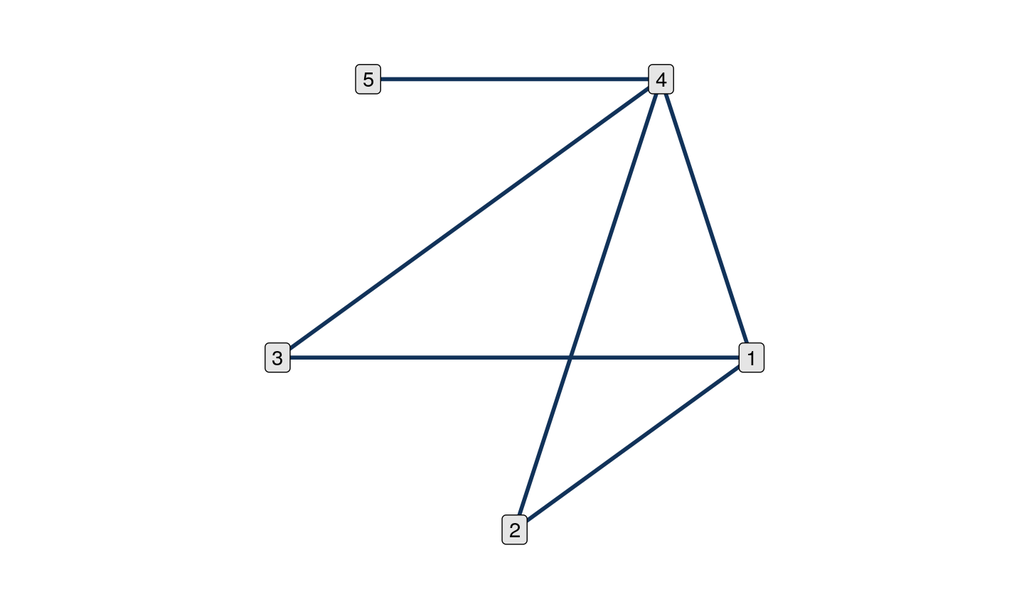

```r
plot(parkinsons_net, weight_edges = FALSE)
```

## cochrane reporting

### intervention effects

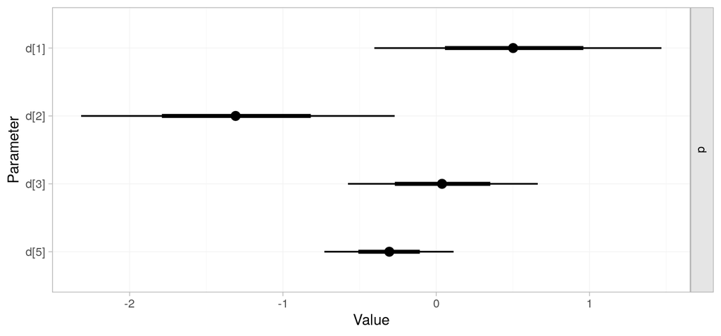

```r
plot(parkinsons_nma)
```

## cochrane reporting

### intervention effects

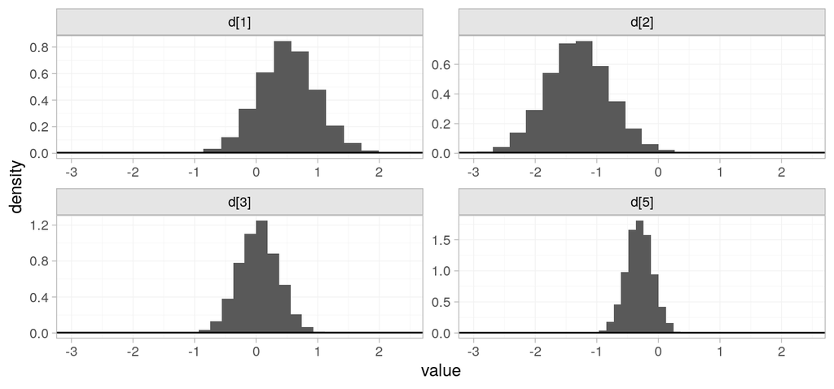

```r
plot_prior_posterior(parkinsons_nma)
```

## cochrane reporting

### ranking

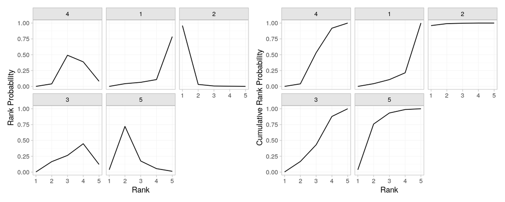

```r
posterior_rank_probs(parkinsons_nma) %>% plot() +
  posterior_rank_probs(parkinsons_nma, cumulative = TRUE) %>% plot()
```

## sensitivity

## leave one out

### exclude a random study from the network meta-analysis

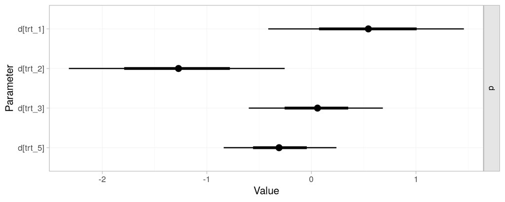

```r
# excluding study
study_to_filter
```

```
## [1] "study_7"
```

## leave m out

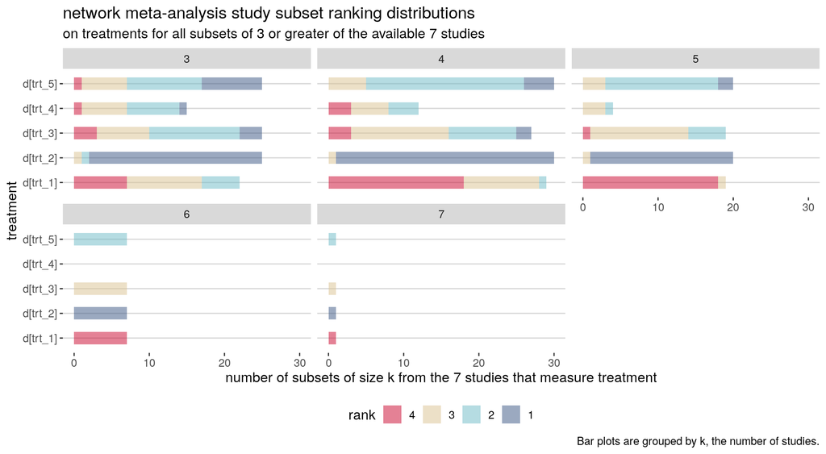

## threshold analysis

### arguments

- posterior mean estimates
- likelihood covariance matrix
- posterior covariance matrix
- design matrix of contrasts

## threshold analysis

### posterior mean estimates

```r
# get posterior mean estimates
post_means <-
  summary(parkinsons_nma, pars=c("d")) %>%
  as.data.frame() %>%
  pull("mean")

# print values
post_means
```

```
##        d[1]        d[2]        d[3]        d[5]
##  0.50845842 -1.30562885  0.04087262 -0.30738230
```

## threshold analysis

### design matrix

[figure not shown]

```
##      [,1] [,2] [,3] [,4]
## [1,]   -1    0    1    0
## [2,]   -1    1    0    0
## [3,]    1    0    0    0
## [4,]    0    0    1    0
## [5,]    0    0    0    1
```

## threshold

### posterior likelihood

```r
Sigma_d <-
  diag(rep(100^2, length(post_means)))
```

## references

Gray, Charles T. 2019. “Code::Proof: Prepare for Most Weather Conditions.” Edited by Hien Nguyen. *Statistics and Data Science*, Communications in Computer and Information Science,, 22–41. https://doi.org/10.1007/978-981-15-1960-4_2.

Parker, Hilary. 2017. “Opinionated Analysis Development.” *Preprint*. https://doi.org/10.7287/peerj.preprints.3210v1.

Wickham, Hadley. 2017. *Tidyverse: Easily Install and Load the ’Tidyverse’*. https://CRAN.R-project.org/package=tidyverse.